# Taiwanese Corporate Bankruptcy Prediction

Rare Event Handling, Boruta Feature Selection, and Bayesian Prior Recalibration

Emilio Manfredi

2026-10-14

## Data Preparation, Oversampling, and Feature Selection (Boruta)

```r
data <- read.csv("data.csv")
prop.table(table(data$Bankrupt.)) # Imbalanced dataset: Bankrupt == 1 is a rare event (~3.2%)
```

```
##
##         0         1
## 0.9677372 0.0322628
```

```r
data$Bankrupt. <- as.factor(data$Bankrupt.)

set.seed(123)
indices <- createDataPartition(data$Bankrupt., p = 0.7, list = FALSE)
train_data <- data[indices, ]
val_data   <- data[-indices, ]

table(train_data$Bankrupt.)
```

```
##
##    0    1
## 4620  154
```

```r
set.seed(123)
n <- nrow(train_data)

oversampled <- train_data %>%
  filter(Bankrupt. == 1) %>%
  sample_n(round(0.3 * n), replace = TRUE) %>%
  bind_rows(filter(train_data, Bankrupt. == 0))

oversampled$Bankrupt <- as.numeric(oversampled$Bankrupt.)
oversampled$Bankrupt. <- NULL

# Target encoding for caret ("c1" = Non-Bankrupt, "c2" = Bankrupt)
y_caret <- as.character(oversampled$Bankrupt)
y_caret <- recode(y_caret, "2" = "c2", "1" = "c1")
oversampled$Bankrupt <- as.factor(y_caret)

table(oversampled$Bankrupt)
```

```
##
##   c1   c2
## 4620 1432
```

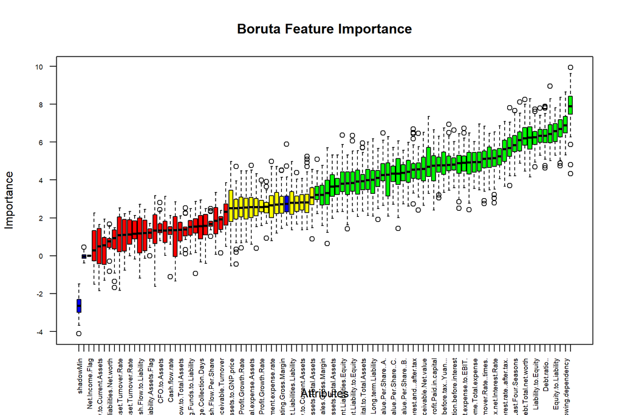

```r
# Disk cache check for Boruta
if (file.exists("boruta_model.rds")) {
  boruta_model <- readRDS("boruta_model.rds")
} else {
  set.seed(123)
  train_data$Bankrupt. <- as.factor(train_data$Bankrupt.)
  boruta_model <- Boruta(Bankrupt. ~ ., data = train_data, doTrace = 0)
  saveRDS(boruta_model, "boruta_model.rds")
}

plot(boruta_model, cex.axis = 0.6, las = 2, main = "Boruta Feature Importance")
```

```r
final_boruta <- TentativeRoughFix(boruta_model)
selected_vars <- getSelectedAttributes(final_boruta, withTentative = FALSE)
cat("Number of variables selected by Boruta:", length(selected_vars), "\n")
```

```
## Number of variables selected by Boruta: 56
```

```r
ds.boruta <- oversampled[, selected_vars]

# Using YeoJohnson instead of BoxCox to safely handle values <= 0 in the validation set
all_together <- preProcess(ds.boruta, method = c("corr", "nzv", "YeoJohnson", "center", "scale"))
global_Xprocessed.total <- clean_newdata(data.frame(predict(all_together, newdata = ds.boruta)))
global_Xprocessed.total$Bankrupt <- oversampled[["Bankrupt"]]

optsol <- 0.5

# Numeric target vectors (0/1) for ASE calculation
y_ASE <- as.numeric(recode(as.character(oversampled$Bankrupt), "c2" = "1", "c1" = "0"))
y_ASE.test <- as.numeric(as.character(val_data$Bankrupt.))

# Sample proportion parameters (rho) and true population priors (true)
rho1 <- 0.70; rho2 <- 0.30
true1 <- 0.97; true2 <- 0.03
```

## STEP 1: Model Training, Prior Recalibration, and Overfitting

In this section, we train and compare 7 different Machine Learning architectures using **5-Fold Cross-Validation**, optimizing the Area Under the ROC Curve (`metric = "ROC"`) or specific classification metrics[cite: 1].

Since the models are trained on the artificially balanced dataset ($\rho_1 = 0.70, \rho_2 = 0.30$), the predicted probabilities are biased relative to the actual incidence of bankruptcies in the market ($\pi_1 = 0.97, \pi_2 = 0.03$)[cite: 1]. Therefore, for each model we apply **Bayes’ correction for true priors**[cite: 1]:

$$\hat{P}(Y = c_2 \mid X) =
\frac{\hat{P}_{over}(Y = c_2 \mid X) \cdot
\frac{\pi_2}{\rho_2}}{\hat{P}_{over}(Y = c_2 \mid X) \cdot
\frac{\pi_2}{\rho_2} + \hat{P}_{over}(Y = c_1 \mid X) \cdot
\frac{\pi_1}{\rho_1}}$$

Finally, we evaluate generalization capability by comparing the **Average Squared Error (ASE)** between the Training Set and the Validation Set[cite: 1].

### Model 1: Penalized Logistic Regression (Lasso)

**Lasso** regression (*Least Absolute Shrinkage and Selection Operator*) introduces an $L_1$-norm penalty into the binomial log-likelihood function ($\alpha = 1$)[cite: 1]:

$$\min_{\beta} \left\{ -\ell(\beta) +
\lambda \sum_{j=1}^{p} \vert{}\beta_j\vert{} \right\}$$

**Behavior in the case study:** In corporate financial statement datasets, many ratios exhibit strong multicollinearity (e.g., multiple correlated profit margins or liquidity ratios)[cite: 1]. The $L_1$ penalty forces the coefficients of redundant variables to exactly zero as the hyperparameter $\lambda$ increases, performing intrinsic *feature selection* that reduces model variance and prevents overfitting[cite: 1].

```r
set.seed(1234)
metric <- "ROC"

# Specific preprocessing: near-zero variance removal and standardization (essential for L1 penalty)
lasso.preProcVal <- preProcess(oversampled, method = c("nzv", "center", "scale"))
lasso.preproc    <- clean_newdata(data.frame(predict(lasso.preProcVal, newdata = oversampled)))
lasso.preproc$Bankrupt <- oversampled$Bankrupt
val_lasso        <- clean_newdata(data.frame(predict(lasso.preProcVal, newdata = val_data)))

grid <- expand.grid(.alpha = 1, .lambda = seq(0, 1, by = 0.01))
Control <- trainControl(method = "cv", number = 5, classProbs = TRUE, summaryFunction = twoClassSummary)

if (file.exists("lasso_model.rds")) {
  lasso_PP <- readRDS("lasso_model.rds")
} else {
  set.seed(1234)
  lasso_PP <- train(Bankrupt ~ ., data = lasso.preproc, method = "glmnet", family = "binomial",
                    trControl = Control, tuneLength = 5, tuneGrid = grid,
                    na.action = na.exclude, metric = metric)
  saveRDS(lasso_PP, "lasso_model.rds")
}

best_lambda <- lasso_PP$bestTune$lambda
cat("Best selected Lambda:", best_lambda, "\n")
```

```
## Best selected Lambda: 0
```

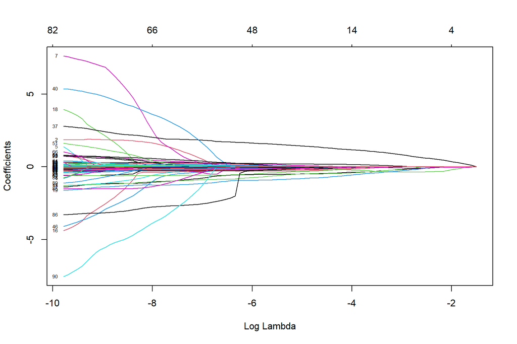

```r
plot(lasso_PP$finalModel, xvar = "lambda", label = TRUE)
```

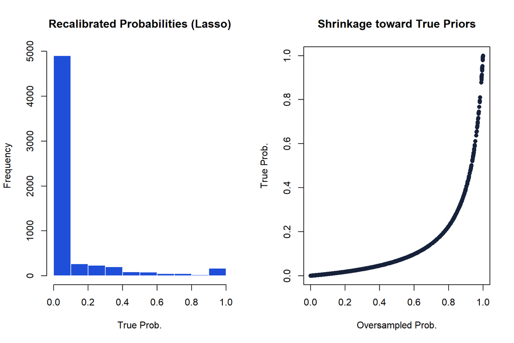

```r
# Recalibration with True Priors
predProb.lasso  <- predict(lasso_PP, lasso.preproc, type = "prob")
predProb2.lasso <- predProb.lasso$c2
predProb1.lasso <- 1 - predProb2.lasso

den.lasso        <- predProb2.lasso * (true2 / rho2) + predProb1.lasso * (true1 / rho1)
pred2_true.lasso <- predProb2.lasso * (true2 / rho2) / den.lasso

par(mfrow = c(1, 2))
hist(pred2_true.lasso, main = "Recalibrated Probabilities (Lasso)", xlab = "True Prob.", col = "#1F4FD8", border = "white")
plot(predProb2.lasso, pred2_true.lasso, main = "Shrinkage toward True Priors", xlab = "Oversampled Prob.", ylab = "True Prob.", col = "#16213A", pch = 16)
```

```r
par(mfrow = c(1, 1))

lasso_prediction_true <- ifelse(pred2_true.lasso > optsol, 2, 1)
table(Actual_Target = y_caret, Lasso_Prediction = lasso_prediction_true)
```

```
##              Lasso_Prediction
## Actual_Target    1    2
##            c1 4596   24
##            c2 1093  339
```

```r
# Overfitting Check (ASE)
train_prob.lasso <- predict(lasso_PP, lasso.preproc, type = "prob")
test_prob.lasso  <- predict(lasso_PP, val_lasso, type = "prob")

train_pred.lasso <- ifelse(train_prob.lasso[, "c2"] > 0.5, 1, 0)
test_pred.lasso  <- ifelse(test_prob.lasso[, "c2"] > 0.5, 1, 0)

train_ASE.lasso  <- mean((y_ASE - train_pred.lasso)^2)
test_ASE.lasso   <- mean((y_ASE.test - test_pred.lasso)^2)
over.lasso       <- ((train_ASE.lasso - test_ASE.lasso) / train_ASE.lasso) * 100

cat("ASE (Training):", round(train_ASE.lasso, 4),
    "| ASE (Test):", round(test_ASE.lasso, 4),
    "| % Change:", round(over.lasso, 2), "%\n")
```

```
## ASE (Training): 0.097 | ASE (Test): 0.0787 | % Change: 18.83 %
```

### Model 2: Naive Bayes

The **Naive Bayes** classifier is a probabilistic generative model based on Bayes’ theorem, which assumes **conditional independence** among features given the class label[cite: 1]:

$$P(Y = c_k \mid X_1, \dots, X_p) \propto
P(Y = c_k) \prod_{j=1}^{p} P(X_j \mid Y = c_k)$$

**Behavior in the case study:** Despite removing the most correlated variables during preprocessing (`method = "corr"`), financial statement data structurally violate the global independence assumption[cite: 1]. Consequently, Naive Bayes tends to produce extreme probability estimates (pushed toward 0 or 1) and exhibits lower discriminative power compared to discriminative or tree-based models[cite: 1].

```r
set.seed(1234)

preProcVal        <- preProcess(oversampled, method = c("corr", "nzv"))
global_Xprocessed <- clean_newdata(data.frame(predict(preProcVal, newdata = oversampled)))
global_Xprocessed$Bankrupt <- oversampled$Bankrupt
val_nb            <- clean_newdata(data.frame(predict(preProcVal, newdata = val_data)))

ctrl <- trainControl(method = "cv", number = 5, classProbs = TRUE, summaryFunction = twoClassSummary)

if (file.exists("nb_model.rds")) {
  naivebayes <- readRDS("nb_model.rds")
} else {
  set.seed(1234)
  naivebayes <- train(Bankrupt ~ ., data = global_Xprocessed, method = "naive_bayes",
                      trControl = ctrl, tuneLength = 5, na.action = na.pass, metric = metric)
  saveRDS(naivebayes, "nb_model.rds")
}

naivebayes
```

```
## Naive Bayes
##
## 6052 samples
##   72 predictor
##    2 classes: 'c1', 'c2'
##
## No pre-processing
## Resampling: Cross-Validated (5 fold)
## Summary of sample sizes: 4842, 4841, 4842, 4842, 4841
## Resampling results across tuning parameters:
##
##   usekernel  ROC        Sens       Spec
##   FALSE      0.8594114  0.1158009  0.9762481
##    TRUE      0.7241616  0.9978355  0.1459662
##
## Tuning parameter 'laplace' was held constant at a value of 0
## Tuning
##  parameter 'adjust' was held constant at a value of 1
## ROC was used to select the optimal model using the largest value.
## The final values used for the model were laplace = 0, usekernel = FALSE
##  and adjust = 1.
```

```r
confusionMatrix(naivebayes)
```

```
## Cross-Validated (5 fold) Confusion Matrix
##
## (entries are percentual average cell counts across resamples)
##
##           Reference
## Prediction   c1   c2
##         c1  8.8  0.6
##         c2 67.5 23.1
##
##  Accuracy (average) : 0.3194
```

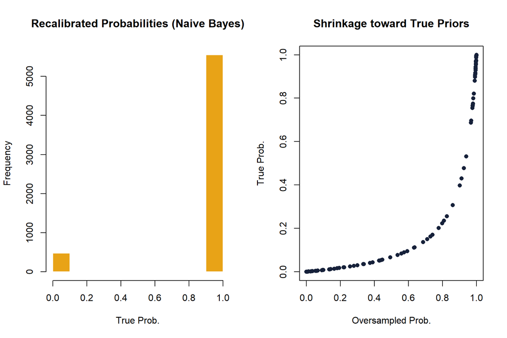

```r
# Recalibration with True Priors
predProb.bayes  <- predict(naivebayes, global_Xprocessed, type = "prob")
predProb2.bayes <- predProb.bayes$c2
predProb1.bayes <- 1 - predProb2.bayes

den.bayes        <- predProb2.bayes * (true2 / rho2) + predProb1.bayes * (true1 / rho1)
pred2_true.bayes <- predProb2.bayes * (true2 / rho2) / den.bayes

par(mfrow = c(1, 2))
hist(pred2_true.bayes, main = "Recalibrated Probabilities (Naive Bayes)", xlab = "True Prob.", col = "#E8A317", border = "white")
plot(predProb2.bayes, pred2_true.bayes, main = "Shrinkage toward True Priors", xlab = "Oversampled Prob.", ylab = "True Prob.", col = "#16213A", pch = 16)
```

```r
par(mfrow = c(1, 1))

bayes_prediction_true <- ifelse(pred2_true.bayes > optsol, 2, 1)
table(Actual_Target = y_caret, NB_Prediction = bayes_prediction_true)
```

```
##              NB_Prediction
## Actual_Target    1    2
##            c1  462 4158
##            c2   25 1407
```

```r
# Overfitting Check (ASE)
train_prob.bayes <- predict(naivebayes, global_Xprocessed, type = "prob")
test_prob.bayes  <- predict(naivebayes, val_nb, type = "prob")

train_pred.bayes <- ifelse(train_prob.bayes[, "c2"] > 0.5, 1, 0)
test_pred.bayes  <- ifelse(test_prob.bayes[, "c2"] > 0.5, 1, 0)

train_ASE.bayes <- mean((y_ASE - train_pred.bayes)^2)
test_ASE.bayes  <- mean((y_ASE.test - test_pred.bayes)^2)
over.bayes      <- ((train_ASE.bayes - test_ASE.bayes) / train_ASE.bayes) * 100

cat("ASE (Training):", round(train_ASE.bayes, 4),
    "| ASE (Test):", round(test_ASE.bayes, 4),
    "| % Change:", round(over.bayes, 2), "%\n")
```

```
## ASE (Training): 0.6946 | ASE (Test): 0.8963 | % Change: -29.03 %
```

### Model 3: Logistic Regression (GLM)

The **Generalized Linear Model (GLM)** with a *logit* link function estimates the probability of default as a linear combination of the predictors selected by Boruta and transformed via Yeo-Johnson[cite: 1]:

$$\log\left(\frac{p}{1-p}\right) = \beta_0
+ \beta_1 X_1 + \dots + \beta_k X_k$$

**Behavior in the case study:** It represents the quintessential parametric benchmark in banking *credit scoring*[cite: 1]. The preliminary application of **Boruta** and the correlation filter allows the GLM to converge smoothly without suffering from numerical instability, yielding well-calibrated probability estimates albeit constrained by the assumption of a linear decision boundary[cite: 1].

```r
set.seed(1234)

val_glm <- clean_newdata(data.frame(predict(all_together, newdata = val_data[, selected_vars])))

if (file.exists("glm_model.rds")) {
  glm <- readRDS("glm_model.rds")
} else {
  set.seed(1234)
  glm <- train(Bankrupt ~ ., data = global_Xprocessed.total, method = "glm",
               trControl = ctrl, tuneLength = 5, trace = FALSE, na.action = na.pass, metric = metric)
  saveRDS(glm, "glm_model.rds")
}

confusionMatrix(glm)
```

```
## Cross-Validated (5 fold) Confusion Matrix
##
## (entries are percentual average cell counts across resamples)
##
##           Reference
## Prediction   c1   c2
##         c1 67.0  5.2
##         c2  9.4 18.5
##
##  Accuracy (average) : 0.8548
```

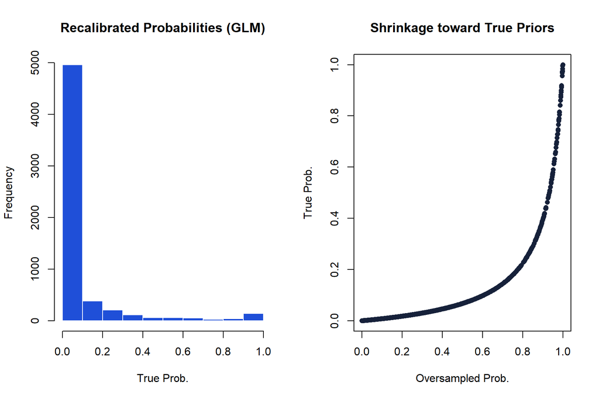

```r
# Recalibration with True Priors
predProb.log  <- predict(glm, global_Xprocessed.total, type = "prob")
predProb2.log <- predProb.log$c2
predProb1.log <- 1 - predProb2.log

den.log        <- predProb2.log * (true2 / rho2) + predProb1.log * (true1 / rho1)
pred2_true.log <- predProb2.log * (true2 / rho2) / den.log

par(mfrow = c(1, 2))
hist(pred2_true.log, main = "Recalibrated Probabilities (GLM)", xlab = "True Prob.", col = "#1F4FD8", border = "white")
plot(predProb2.log, pred2_true.log, main = "Shrinkage toward True Priors", xlab = "Oversampled Prob.", ylab = "True Prob.", col = "#16213A", pch = 16)
```

```r
par(mfrow = c(1, 1))

logit_prediction_true <- ifelse(pred2_true.log > optsol, 2, 1)
table(Actual_Target = y_caret, GLM_Prediction = logit_prediction_true)
```

```
##              GLM_Prediction
## Actual_Target    1    2
##            c1 4591   29
##            c2 1142  290
```

```r
# Overfitting Check (ASE)
train_prob.glm <- predict(glm, global_Xprocessed.total, type = "prob")
test_prob.glm  <- predict(glm, val_glm, type = "prob")

train_pred.glm <- ifelse(train_prob.glm[, "c2"] > 0.5, 1, 0)
test_pred.glm  <- ifelse(test_prob.glm[, "c2"] > 0.5, 1, 0)

train_ASE.glm <- mean((y_ASE - train_pred.glm)^2, na.rm = TRUE)
test_ASE.glm  <- mean((y_ASE.test - test_pred.glm)^2, na.rm = TRUE)
over.glm      <- ((train_ASE.glm - test_ASE.glm) / train_ASE.glm) * 100

cat("ASE (Training):", round(train_ASE.glm, 4),
    "| ASE (Test):", round(test_ASE.glm, 4),
    "| % Change:", round(over.glm, 2), "%\n")
```

```
## ASE (Training): 0.1191 | ASE (Test): 0.0704 | % Change: 40.89 %
```

### Model 4: K-Nearest Neighbors (K-NN)

**K-NN** is a non-parametric, *instance-based* algorithm that classifies an observation based on the majority class among its $k$ nearest neighbors in the Euclidean feature space[cite: 1].

**Behavior in the case study:** Because it relies on geometric distance calculations, K-NN strictly requires standardization (`center` and `scale`) and dimensionality reduction via Boruta to mitigate the *curse of dimensionality*[cite: 1]. With oversampling (which duplicates minority class observations), small values of $k$ tend to capture local clusters of insolvent firms very well, but expose the model to a higher risk of overfitting to local noise[cite: 1].

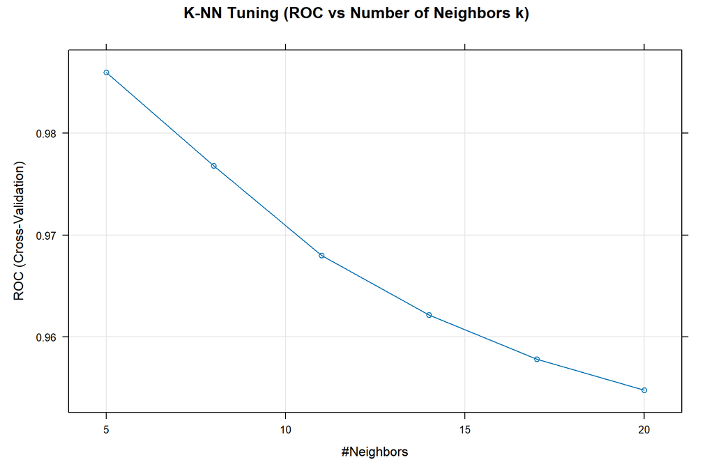

```r
set.seed(1234)

preProcVal.knn  <- preProcess(ds.boruta, method = c("scale", "corr", "center", "nzv"))
df.knn          <- clean_newdata(data.frame(predict(preProcVal.knn, newdata = ds.boruta)))
df.knn$Bankrupt <- oversampled$Bankrupt
val_knn         <- clean_newdata(data.frame(predict(preProcVal.knn, newdata = val_data[, selected_vars])))

grid_knn <- expand.grid(k = seq(5, 20, 3))

if (file.exists("knn_model.rds")) {
  knn <- readRDS("knn_model.rds")
} else {
  set.seed(1234)
  knn <- train(Bankrupt ~ ., data = df.knn, method = "knn",
               trControl = ctrl, tuneLength = 5, na.action = na.pass,
               tuneGrid = grid_knn, metric = metric)
  saveRDS(knn, "knn_model.rds")
}

plot(knn, main = "K-NN Tuning (ROC vs Number of Neighbors k)")
```

```r
confusionMatrix(knn)
```

```
## Cross-Validated (5 fold) Confusion Matrix
##
## (entries are percentual average cell counts across resamples)
##
##           Reference
## Prediction   c1   c2
##         c1 69.5  0.4
##         c2  6.8 23.3
##
##  Accuracy (average) : 0.9278
```

```r
# Recalibration with True Priors
predProb.knn  <- predict(knn, df.knn, type = "prob")
predProb2.knn <- predProb.knn$c2
predProb1.knn <- 1 - predProb2.knn

den.knn        <- predProb2.knn * (true2 / rho2) + predProb1.knn * (true1 / rho1)
pred2_true.knn <- predProb2.knn * (true2 / rho2) / den.knn

knn_prediction_true <- ifelse(pred2_true.knn > optsol, 2, 1)
table(Actual_Target = y_caret, KNN_Prediction = knn_prediction_true)
```

```
##              KNN_Prediction
## Actual_Target    1    2
##            c1 4606   14
##            c2   11 1421
```

```r
# Overfitting Check (ASE)
train_prob.knn <- predict(knn, df.knn, type = "prob")
test_prob.knn  <- predict(knn, val_knn, type = "prob")

train_pred.knn <- ifelse(train_prob.knn[, "c2"] > 0.5, 1, 0)
test_pred.knn  <- ifelse(test_prob.knn[, "c2"] > 0.5, 1, 0)

train_ASE.knn <- mean((y_ASE - train_pred.knn)^2)
test_ASE.knn  <- mean((y_ASE.test - test_pred.knn)^2)
over.knn      <- ((train_ASE.knn - test_ASE.knn) / train_ASE.knn) * 100

cat("ASE (Training):", round(train_ASE.knn, 4),
    "| ASE (Test):", round(test_ASE.knn, 4),
    "| % Change:", round(over.knn, 2), "%\n")
```

```
## ASE (Training): 0.0491 | ASE (Test): 0.0929 | % Change: -89.32 %
```

### Model 5: Random Forest

**Random Forest** is an *ensemble* method based on **Bagging** (*Bootstrap Aggregating*) of unpruned decision trees, combined with random sampling of a subset of features (`mtry`) at each split[cite: 1].

**Behavior in the case study:** Decision trees natively capture complex non-linear interactions and critical thresholds in financial statements (e.g., a company that goes bankrupt only when simultaneously experiencing high leverage *and* low liquidity)[cite: 1]. Furthermore, they are invariant to monotonic transformations of variables (requiring no scaling)[cite: 1]. Tree decorrelation ensures outstanding predictive performance (among the highest AUCs overall), although training error physiologically approaches zero[cite: 1].

```r
set.seed(1234)
cvCtrl <- trainControl(method = "cv", number = 5, search = "grid", classProbs = TRUE, summaryFunction = twoClassSummary)

if (file.exists("rf_model.rds")) {
  rf <- readRDS("rf_model.rds")
} else {
  set.seed(1234)
  rf <- train(Bankrupt ~ ., data = oversampled, method = "rf", trControl = cvCtrl, metric = metric)
  saveRDS(rf, "rf_model.rds")
}

rf
```

```
## Random Forest
##
## 6052 samples
##   95 predictor
##    2 classes: 'c1', 'c2'
##
## No pre-processing
## Resampling: Cross-Validated (5 fold)
## Summary of sample sizes: 4842, 4841, 4842, 4842, 4841
## Resampling results across tuning parameters:
##
##   mtry  ROC        Sens       Spec
##    2    0.9999939  0.9919913  1
##   48    0.9999788  0.9880952  1
##   95    0.9999713  0.9861472  1
##
## ROC was used to select the optimal model using the largest value.
## The final value used for the model was mtry = 2.
```

```r
getTrainPerf(rf)
```

```
##    TrainROC TrainSens TrainSpec method
## 1 0.9999939 0.9919913         1     rf
```

```r
confusionMatrix(rf)
```

```
## Cross-Validated (5 fold) Confusion Matrix
##
## (entries are percentual average cell counts across resamples)
##
##           Reference
## Prediction   c1   c2
##         c1 75.7  0.0
##         c2  0.6 23.7
##
##  Accuracy (average) : 0.9939
```

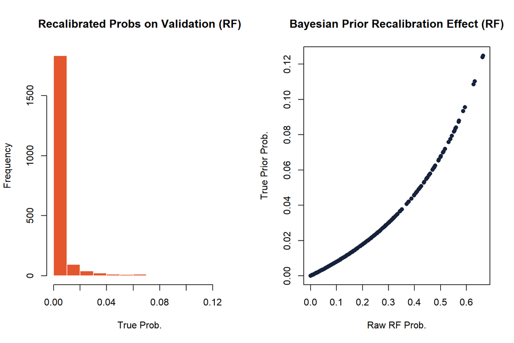

```r
# Recalibration with True Priors directly on the Validation Set (for subsequent Steps)
predProb.rf  <- predict(rf, val_data, type = "prob")
predProb2.rf <- predProb.rf$c2
predProb1.rf <- 1 - predProb2.rf

den.rf        <- predProb2.rf * (true2 / rho2) + predProb1.rf * (true1 / rho1)
pred2_true.rf <- predProb2.rf * (true2 / rho2) / den.rf
pred1_true.rf <- predProb1.rf * (true1 / rho1) / den.rf

par(mfrow = c(1, 2))
hist(pred2_true.rf, main = "Recalibrated Probs on Validation (RF)", xlab = "True Prob.", col = "#E4572E", border = "white")
plot(predProb2.rf, pred2_true.rf, main = "Bayesian Prior Recalibration Effect (RF)", xlab = "Raw RF Prob.", ylab = "True Prior Prob.", col = "#16213A", pch = 16)
```

```r
par(mfrow = c(1, 1))

# Overfitting Check (ASE)
train_prob.rf <- predict(rf, oversampled, type = "prob")
test_prob.rf  <- predict(rf, val_data, type = "prob")

train_pred.rf <- ifelse(train_prob.rf[, "c2"] > 0.5, 1, 0)
test_pred.rf  <- ifelse(test_prob.rf[, "c2"] > 0.5, 1, 0)

train_ASE.rf <- mean((y_ASE - train_pred.rf)^2)
test_ASE.rf  <- mean((y_ASE.test - test_pred.rf)^2)
over.rf      <- ((train_ASE.rf - test_ASE.rf) / train_ASE.rf) * 100

cat("ASE (Training):", round(train_ASE.rf, 4),
    "| ASE (Test):", round(test_ASE.rf, 4), "\n")
```

```
## ASE (Training): 0 | ASE (Test): 0.0308
```

### Model 6: Artificial Neural Networks (MLP - Grid & Random Search)

We train a *Multi-Layer Perceptron* neural network (`nnet` package) with a single hidden layer[cite: 1]. We explore the hyperparameter space — number of hidden units (`size`) and $L_2$ regularization on synaptic weights (`decay`, *weight decay*) — comparing two search strategies: **Grid Search** (optimized for Specificity) and **Random Search** (optimized for Accuracy)[cite: 1].

**Behavior in the case study:** Neural networks are universal approximators capable of modeling highly non-linear relationships[cite: 1]. However, they require input normalization to the $[0, 1]$ range (`preProcess = "range"`) to prevent saturation of logistic activation functions, as well as an appropriate `decay` parameter to prevent the network from memorizing data points duplicated by oversampling[cite: 1].

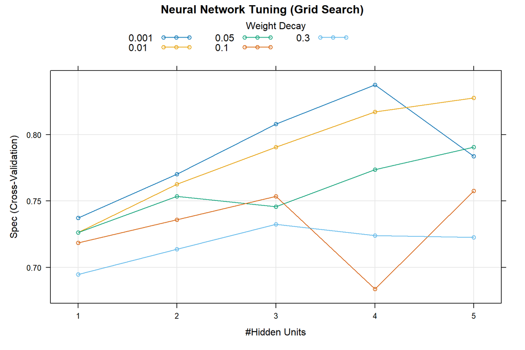

```r
set.seed(1234)
target_col_idx <- which(names(global_Xprocessed.total) == "Bankrupt")

# Strict cleaning of val_nn against NA/NaN/Inf
val_nn <- clean_newdata(data.frame(predict(all_together, newdata = val_data[, selected_vars])))

# 6.1 Grid Search Architecture (focus on Specificity)
ctrl_nnd <- trainControl(method = "cv", number = 5, search = "grid", classProbs = TRUE, summaryFunction = twoClassSummary)
tunegrid <- expand.grid(size = c(1:5), decay = c(0.001, 0.01, 0.05, 0.1, 0.3))

if (file.exists("nnet_grid_model.rds")) {
  nnetFit_def <- readRDS("nnet_grid_model.rds")
} else {
  set.seed(1234)
  nnetFit_def <- train(x = global_Xprocessed.total[, -target_col_idx],
                       y = global_Xprocessed.total$Bankrupt,
                       method = "nnet", preProcess = "range",
                       metric = "Spec", trControl = ctrl_nnd, tuneGrid = tunegrid,
                       trace = FALSE, maxit = 300)
  saveRDS(nnetFit_def, "nnet_grid_model.rds")
}

plot(nnetFit_def, main = "Neural Network Tuning (Grid Search)")
```

```r
confusionMatrix(nnetFit_def)
```

```
## Cross-Validated (5 fold) Confusion Matrix
##
## (entries are percentual average cell counts across resamples)
##
##           Reference
## Prediction   c1   c2
##         c1 71.5  3.8
##         c2  4.8 19.8
##
##  Accuracy (average) : 0.9136
```

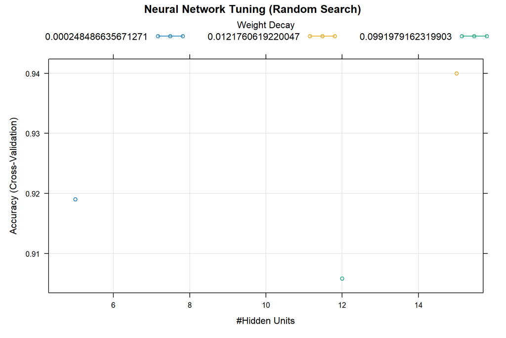

```r
# 6.2 Random Search Architecture (focus on Accuracy)
ctrl_nnr <- trainControl(method = "cv", number = 5, search = "random", classProbs = TRUE)

if (file.exists("nnet_rand_model.rds")) {
  nnetFit_random <- readRDS("nnet_rand_model.rds")
} else {
  set.seed(1234)
  nnetFit_random <- train(x = global_Xprocessed.total[, -target_col_idx],
                          y = global_Xprocessed.total$Bankrupt,
                          method = "nnet", preProcess = "range",
                          metric = "Accuracy", trControl = ctrl_nnr,
                          trace = FALSE, maxit = 300)
  saveRDS(nnetFit_random, "nnet_rand_model.rds")
}

plot(nnetFit_random, main = "Neural Network Tuning (Random Search)")
```

```r
confusionMatrix(nnetFit_random)
```

```
## Cross-Validated (5 fold) Confusion Matrix
##
## (entries are percentual average cell counts across resamples)
##
##           Reference
## Prediction   c1   c2
##         c1 72.3  2.0
##         c2  4.0 21.7
##
##  Accuracy (average) : 0.94
```

```r
# Overfitting Check NN1 (Grid) and NN2 (Random)
train_prob.nnd <- predict(nnetFit_def, global_Xprocessed.total[, -target_col_idx], type = "prob")
test_prob.nnd  <- predict(nnetFit_def, val_nn, type = "prob")
train_ASE.nnd  <- mean((y_ASE - ifelse(train_prob.nnd[, "c2"] > 0.5, 1, 0))^2)
test_ASE.nnd   <- mean((y_ASE.test - ifelse(test_prob.nnd[, "c2"] > 0.5, 1, 0))^2)

train_prob.nnr <- predict(nnetFit_random, global_Xprocessed.total[, -target_col_idx], type = "prob")
test_prob.nnr  <- predict(nnetFit_random, val_nn, type = "prob")
train_ASE.nnr  <- mean((y_ASE - ifelse(train_prob.nnr[, "c2"] > 0.5, 1, 0))^2)
test_ASE.nnr   <- mean((y_ASE.test - ifelse(test_prob.nnr[, "c2"] > 0.5, 1, 0))^2)

cat("NNet Grid   -> ASE (Train):", round(train_ASE.nnd, 4), "| ASE (Test):", round(test_ASE.nnd, 4), "\n")
```

```
## NNet Grid   -> ASE (Train): 0.0783 | ASE (Test): 0.0797
```

```r
cat("NNet Random -> ASE (Train):", round(train_ASE.nnr, 4), "| ASE (Test):", round(test_ASE.nnr, 4), "\n")
```

```
## NNet Random -> ASE (Train): 0.0444 | ASE (Test): 0.0685
```

### Model 7: Gradient Boosting Machine (GBM)

Unlike Random Forest (which builds deep, independent trees in parallel to reduce variance), **Gradient Boosting** builds shallow decision trees (*weak learners*) **sequentially**[cite: 1]. Each new tree is trained on the pseudo-residuals (the negative gradient of the loss function) of the preceding ensemble[cite: 1].

**Behavior in the case study:** Boosting systematically reduces *bias* by focusing on the hardest-to-classify observations (“borderline” companies between solvency and insolvency)[cite: 1]. It proves to be one of the best-performing and most stable models across the entire Validation Set, maintaining a narrow gap between training and test error thanks to the shallow depth of individual trees[cite: 1].

```r
set.seed(1234)
metric <- "ROC"

if (file.exists("gb_model.rds")) {
  gb <- readRDS("gb_model.rds")
} else {
  set.seed(1234)
  gb <- train(Bankrupt ~ ., data = oversampled, method = "gbm", trControl = cvCtrl, metric = metric, verbose = FALSE)
  saveRDS(gb, "gb_model.rds")
}

gb
```

```
## Stochastic Gradient Boosting
##
## 6052 samples
##   95 predictor
##    2 classes: 'c1', 'c2'
##
## No pre-processing
## Resampling: Cross-Validated (5 fold)
## Summary of sample sizes: 4842, 4841, 4842, 4842, 4841
## Resampling results across tuning parameters:
##
##   interaction.depth  n.trees  ROC        Sens       Spec
##   1                   50      0.9551165  0.9619048  0.7129700
##   1                  100      0.9635738  0.9560606  0.7953827
##   1                  150      0.9693486  0.9547619  0.8261153
##   2                   50      0.9693561  0.9577922  0.8184498
##   2                  100      0.9780064  0.9569264  0.8673327
##   2                  150      0.9832523  0.9625541  0.9120246
##   3                   50      0.9750737  0.9586580  0.8533515
##   3                  100      0.9842060  0.9623377  0.9189981
##   3                  150      0.9887826  0.9653680  0.9504203
##
## Tuning parameter 'shrinkage' was held constant at a value of 0.1
##
## Tuning parameter 'n.minobsinnode' was held constant at a value of 10
## ROC was used to select the optimal model using the largest value.
## The final values used for the model were n.trees = 150, interaction.depth =
##  3, shrinkage = 0.1 and n.minobsinnode = 10.
```

```r
getTrainPerf(gb)
```

```
##    TrainROC TrainSens TrainSpec method
## 1 0.9887826  0.965368 0.9504203    gbm
```

```r
confusionMatrix(gb)
```

```
## Cross-Validated (5 fold) Confusion Matrix
##
## (entries are percentual average cell counts across resamples)
##
##           Reference
## Prediction   c1   c2
##         c1 73.7  1.2
##         c2  2.6 22.5
##
##  Accuracy (average) : 0.9618
```

```r
# Overfitting Check (ASE)
train_prob.gb <- predict(gb, oversampled, type = "prob")
test_prob.gb  <- predict(gb, val_data, type = "prob")

train_pred.gb <- ifelse(train_prob.gb[, "c2"] > 0.5, 1, 0)
test_pred.gb  <- ifelse(test_prob.gb[, "c2"] > 0.5, 1, 0)

train_ASE.gb <- mean((y_ASE - train_pred.gb)^2)
test_ASE.gb  <- mean((y_ASE.test - test_pred.gb)^2)
over.gb      <- ((train_ASE.gb - test_ASE.gb) / train_ASE.gb) * 100

cat("ASE (Training):", round(train_ASE.gb, 4),
    "| ASE (Test):", round(test_ASE.gb, 4),
    "| % Change:", round(over.gb, 2), "%\n")
```

```
## ASE (Training): 0.0254 | ASE (Test): 0.0445 | % Change: -74.87 %
```

## STEP 2: Model Comparison on the Validation Set (ROC and Gain/Lift)

We compare the performance of all trained models on the **Validation Set** (which reflects the true market distribution, with only ~3.2% bankruptcies) using two evaluation tools[cite: 1]: 1. **ROC Curves and AUC:** Measure the global ranking capability of the model across all possible cutoff thresholds[cite: 1]. 2. **Gain & Lift Analysis:** Measures how many times more effective the model is compared to random selection in capturing bankruptcies within the top risk deciles (e.g., focusing audits on the top 10%–30% highest-scoring firms)[cite: 1].

```r
# Probability score calculation (class c2 = Bankrupt) on the Validation Set
val_scores <- data.frame(Bankrupt. = val_data$Bankrupt.)
val_scores$knn            <- predict(knn, val_knn, type = "prob")[, "c2"]
val_scores$glm            <- predict(glm, val_glm, type = "prob")[, "c2"]
val_scores$lasso_PP       <- predict(lasso_PP, val_lasso, type = "prob")[, "c2"]
val_scores$naivebayes     <- predict(naivebayes, val_nb, type = "prob")[, "c2"]
val_scores$rf             <- predict(rf, val_data, type = "prob")[, "c2"]
val_scores$nnetFit_def    <- predict(nnetFit_def, val_nn, type = "prob")[, "c2"]
val_scores$nnetFit_random <- predict(nnetFit_random, val_nn, type = "prob")[, "c2"]
val_scores$gb             <- predict(gb, val_data, type = "prob")[, "c2"]

# ROC objects calculation
roc.glm        <- roc(val_scores$Bankrupt., val_scores$glm, quiet = TRUE)
roc.knn        <- roc(val_scores$Bankrupt., val_scores$knn, quiet = TRUE)
roc.lasso_PP   <- roc(val_scores$Bankrupt., val_scores$lasso_PP, quiet = TRUE)
roc.naivebayes <- roc(val_scores$Bankrupt., val_scores$naivebayes, quiet = TRUE)
roc.rf         <- roc(val_scores$Bankrupt., val_scores$rf, quiet = TRUE)
roc.nnd        <- roc(val_scores$Bankrupt., val_scores$nnetFit_def, quiet = TRUE)
roc.nnr        <- roc(val_scores$Bankrupt., val_scores$nnetFit_random, quiet = TRUE)
roc.gb         <- roc(val_scores$Bankrupt., val_scores$gb, quiet = TRUE)

# Summary Table of Validation AUC and ASE
summary_table <- data.frame(
  Model = c("Random Forest", "Gradient Boosting", "GLM (Logistic)", "Neural Net (Grid)", "Neural Net (Random)", "K-NN", "Lasso", "Naive Bayes"),
  AUC_Validation = round(c(auc(roc.rf), auc(roc.gb), auc(roc.glm), auc(roc.nnd), auc(roc.nnr), auc(roc.knn), auc(roc.lasso_PP), auc(roc.naivebayes)), 4),
  ASE_Train = round(c(train_ASE.rf, train_ASE.gb, train_ASE.glm, train_ASE.nnd, train_ASE.nnr, train_ASE.knn, train_ASE.lasso, train_ASE.bayes), 4),
  ASE_Validation = round(c(test_ASE.rf, test_ASE.gb, test_ASE.glm, test_ASE.nnd, test_ASE.nnr, test_ASE.knn, test_ASE.lasso, test_ASE.bayes), 4)
)
knitr::kable(summary_table[order(-summary_table$AUC_Validation), ], row.names = FALSE, caption = "Model Ranking by Validation Set AUC")
```

Model Ranking by Validation Set AUC

| Model | AUC_Validation | ASE_Train | ASE_Validation |
| --- | --- | --- | --- |
| Random Forest | 0.9442 | 0.0000 | 0.0308 |
| Gradient Boosting | 0.9327 | 0.0254 | 0.0445 |
| GLM (Logistic) | 0.8743 | 0.1191 | 0.0704 |
| Neural Net (Random) | 0.8693 | 0.0444 | 0.0685 |
| Neural Net (Grid) | 0.8528 | 0.0783 | 0.0797 |
| Lasso | 0.8182 | 0.0970 | 0.0787 |
| K-NN | 0.7826 | 0.0491 | 0.0929 |
| Naive Bayes | 0.5579 | 0.6946 | 0.8963 |

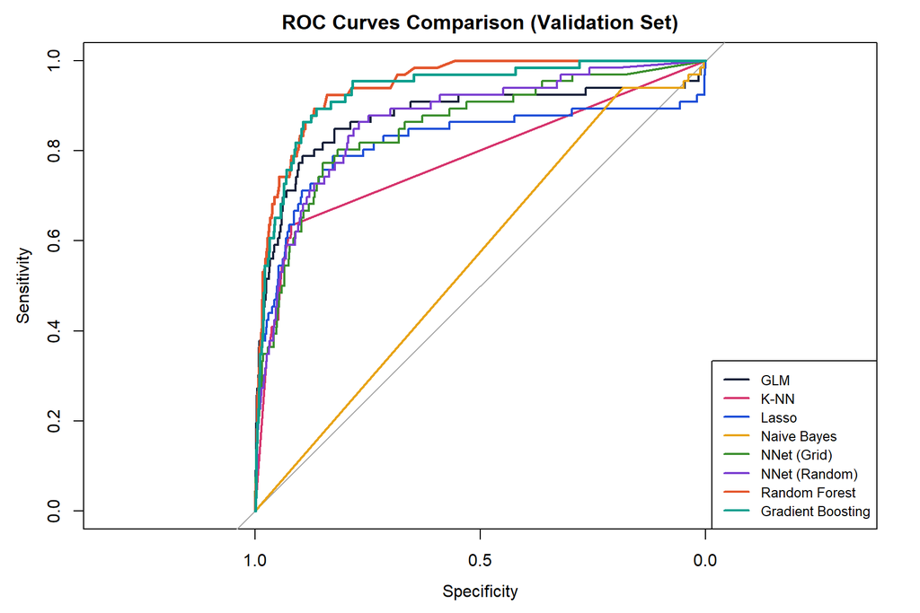

```r
# Comparative ROC Curves Plot
plot(roc.glm, main = "ROC Curves Comparison (Validation Set)", col = "#16213A", lwd = 2)
plot(roc.knn, add = TRUE, col = "#D6336C", lwd = 2)
plot(roc.lasso_PP, add = TRUE, col = "#1F4FD8", lwd = 2)
plot(roc.naivebayes, add = TRUE, col = "#E8A317", lwd = 2)
plot(roc.nnd, add = TRUE, col = "#3B8F2E", lwd = 2)
plot(roc.nnr, add = TRUE, col = "#7B3FD1", lwd = 2)
plot(roc.rf, add = TRUE, col = "#E4572E", lwd = 2.5)
plot(roc.gb, add = TRUE, col = "#0E9F8E", lwd = 2.5)
legend("bottomright",
       legend = c("GLM", "K-NN", "Lasso", "Naive Bayes", "NNet (Grid)", "NNet (Random)", "Random Forest", "Gradient Boosting"),
       col = c("#16213A", "#D6336C", "#1F4FD8", "#E8A317", "#3B8F2E", "#7B3FD1", "#E4572E", "#0E9F8E"),
       lty = 1, lwd = 2, cex = 0.8)
```

### Gain & Lift Analysis on Top Models

Looking at the 3rd decile (the top 30% of companies classified as highest risk), both Random Forest and Gradient Boosting achieve a **Lift above 3.1** (capturing over 90% of total bankruptcies while inspecting only 30% of the portfolio)[cite: 1].

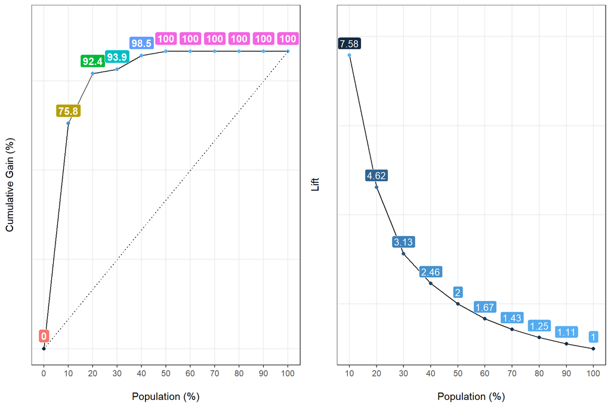

```
##    Population   Gain Lift Score.Point
## 1          10  75.76 7.58      0.1292
## 2          20  92.42 4.62      0.0440
## 3          30  93.94 3.13      0.0220
## 4          40  98.48 2.46      0.0100
## 5          50 100.00 2.00      0.0060
## 6          60 100.00 1.67      0.0020
## 7          70 100.00 1.43      0.0020
## 8          80 100.00 1.25      0.0000
## 9          90 100.00 1.11      0.0000
## 10        100 100.00 1.00      0.0000
```

```r
gain_lift(data = val_scores, score = 'rf', target = 'Bankrupt.')
```

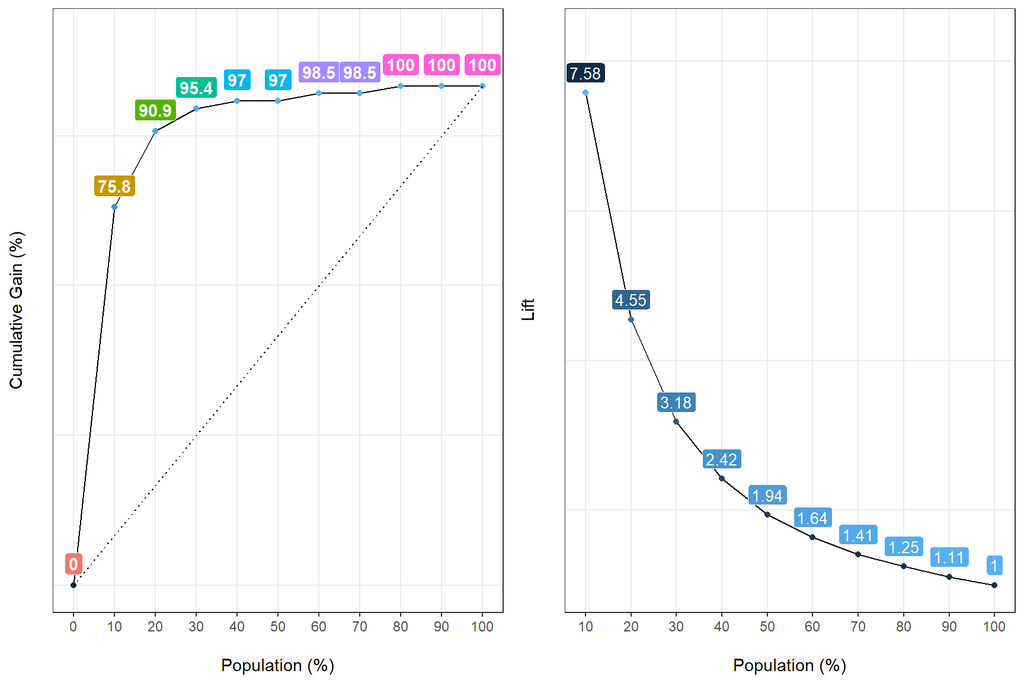

```
##    Population   Gain Lift Score.Point
## 1          10  75.76 7.58 0.247278880
## 2          20  90.91 4.55 0.059710304
## 3          30  95.45 3.18 0.026263876
## 4          40  96.97 2.42 0.015104420
## 5          50  96.97 1.94 0.010739610
## 6          60  98.48 1.64 0.008556532
## 7          70  98.48 1.41 0.007304735
## 8          80 100.00 1.25 0.006332871
## 9          90 100.00 1.11 0.005720005
## 10        100 100.00 1.00 0.004230463
```

```r
gain_lift(data = val_scores, score = 'gb', target = 'Bankrupt.')
```

## STEP 3 & 4: Decision Threshold Optimization and Final Evaluation

Once **Random Forest** is selected and its predicted probabilities on the Validation Set are recalibrated using the true population priors (`pred2_true.rf`), using a standard cutoff threshold of $0.5$ would be suboptimal for a rare event[cite: 1].

We therefore examine the behavior of **Sensitivity (Recall)**, **Specificity**, **Precision**, and **F1-Measure** across the continuous range of decision thresholds, selecting the cutoff that **maximizes the F1-Measure**[cite: 1]:

$$F_1 = 2 \cdot \frac{\text{Precision}
\cdot \text{Sensitivity}}{\text{Precision} +
\text{Sensitivity}}$$

```r
# Creating ROCR object on Random Forest recalibrated probabilities
target_binary <- ifelse(val_data$Bankrupt. == "1", 1, 0)
predRoc       <- prediction(pred2_true.rf, target_binary)

acc.f     <- performance(predRoc, measure = "f")
spec.perf <- performance(predRoc, measure = "spec")
sens.perf <- performance(predRoc, measure = "sens")
prec.perf <- performance(predRoc, measure = "prec")

# Extracting the optimal cutoff that maximizes the F1-Measure
f_values      <- unlist(acc.f@y.values)
cutoff_values <- unlist(acc.f@x.values)
best_index    <- which.max(f_values)
best_fmeasure <- f_values[best_index]
best_cutoff   <- cutoff_values[best_index]

cat("Best Cutoff (F1-Max):", round(best_cutoff, 4),
    "| Maximum F1-Measure achieved:", round(best_fmeasure, 4), "\n")
```

```
## Best Cutoff (F1-Max): 0.032 | Maximum F1-Measure achieved: 0.5224
```

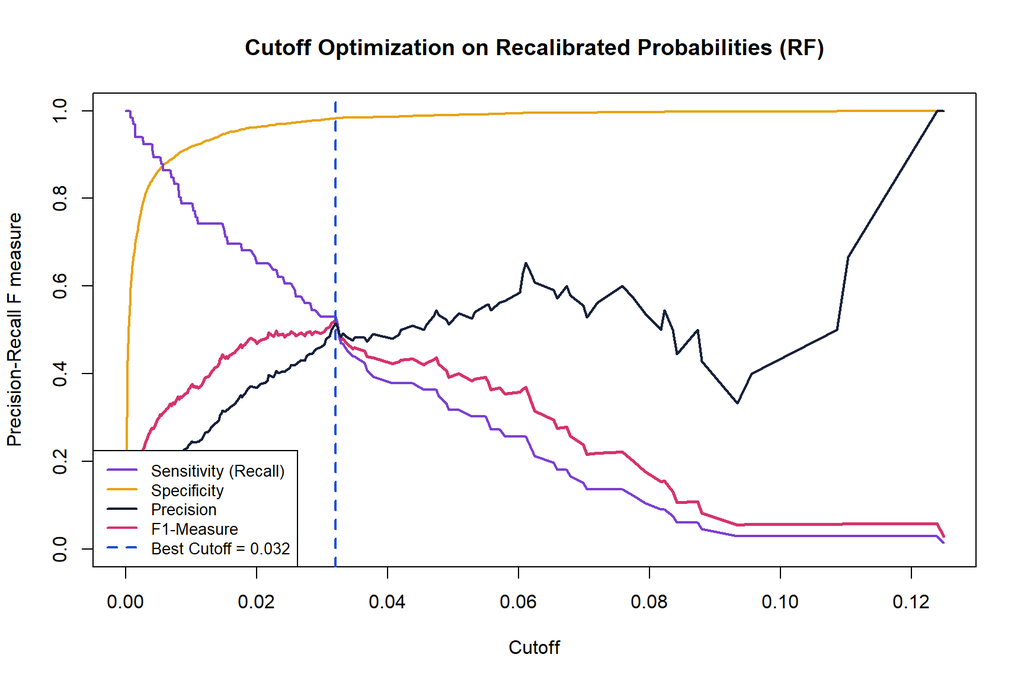

```r
# Metrics trade-off plot
plot(acc.f, col = "#D6336C", ylim = c(0, 1), lwd = 2.5, main = "Cutoff Optimization on Recalibrated Probabilities (RF)")
plot(spec.perf, add = TRUE, col = "#E8A317", lwd = 2)
plot(sens.perf, add = TRUE, col = "#7B3FD1", lwd = 2)
plot(prec.perf, add = TRUE, col = "#16213A", lwd = 2)
abline(v = best_cutoff, col = "#1F4FD8", lty = 2, lwd = 2)
legend("bottomleft",
       legend = c("Sensitivity (Recall)", "Specificity", "Precision", "F1-Measure", paste("Best Cutoff =", round(best_cutoff, 3))),
       col = c("#7B3FD1", "#E8A317", "#16213A", "#D6336C", "#1F4FD8"),
       lty = c(1, 1, 1, 1, 2), lwd = 2, cex = 0.85)
```

```r
# Step 4: Final Confusion Matrix on the Validation Set
actual_factor <- factor(ifelse(target_binary == 1, "c1", "c0"), levels = c("c0", "c1"))
pred_factor   <- factor(ifelse(pred2_true.rf > best_cutoff, "c1", "c0"), levels = c("c0", "c1"))

confusionMatrix(pred_factor, actual_factor, positive = "c1")
```

```
## Confusion Matrix and Statistics
##
##           Reference
## Prediction   c0   c1
##         c0 1946   32
##         c1   33   34
##
##                Accuracy : 0.9682
##                  95% CI : (0.9597, 0.9754)
##     No Information Rate : 0.9677
##     P-Value [Acc > NIR] : 0.4828
##
##                   Kappa : 0.4949
##
##  Mcnemar's Test P-Value : 1.0000
##
##             Sensitivity : 0.51515
##             Specificity : 0.98332
##          Pos Pred Value : 0.50746
##          Neg Pred Value : 0.98382
##              Prevalence : 0.03227
##          Detection Rate : 0.01663
##    Detection Prevalence : 0.03276
##       Balanced Accuracy : 0.74924
##
##        'Positive' Class : c1
##
```

```r
# Consistency check with the true population distribution
count_c1 <- sum(actual_factor == "c1")
cat("True proportion of bankruptcies in the Validation Set:", round(count_c1 / nrow(val_data), 4), "\n")
```

```
## True proportion of bankruptcies in the Validation Set: 0.0323
```